# Dirty Data Project

Geraldine A.

March 24, 2023

# Introduction

The dataset used in this analysis was collected from surveys conducted between 2015 and 2017, which gathered responses from individuals across various countries including the UK, USA, Spain, the Netherlands, and other European and Asian countries. The surveys asked participants to rate their level of satisfaction (on a scale of Joy, Despair, or Meh) when receiving different types of candies and treats during Halloween.

The purpose of this analysis is to identify patterns and insights within the dataset to better understand the preferences and satisfaction levels of individuals when it comes to Halloween candies and treats. By analyzing the data, we hope to gain a deeper understanding of the factors that influence people’s satisfaction levels and how these factors differ across various countries and regions.

In the following sections, we will explore the dataset and present our findings in a clear and concise manner.

## Data

For this analysis, I worked with three different data files that needed to be standardized, cleaned, and merged into a single file. The cleaning process involved removing any missing or incorrect data and handling inconsistencies in the formatting of the data.

One of the biggest challenges I encountered during the cleaning process was the lack of validation in the “country” column of the survey data. Respondents were allowed to enter any value they wanted in this column, leading to a large number of invalid or nonsensical responses. To address this issue, I implemented a process to identify and correct any erroneous data in the “country” column.

Despite these challenges, I was able to successfully prepare the data for analysis and extract valuable insights from it. The next sections will describe the analysis I performed on the data and the results I obtained.

## Analysis and visualisations

#### Total number of candy ratings given across the three years:

| total_sum_ratings |
| --- |
| 737727 |

#### Average age of people who are going out trick or treating?

| avg_age |
| --- |
| 35 |

#### Average age of people who are not going trick or treating?

| avg_age |
| --- |
| 39 |

#### For each of joy, despair and meh, Which candy bar received the most of these ratings?

| candy_bar | rating_count |
| --- | --- |
| any_full_sized_candy_bar | 7246 |
| kit_kat | 6912 |
| twix | 6684 |
| snickers | 6660 |
| tolberone_something_or_other | 5897 |
| nestle_crunch | 5840 |
| butterfinger | 5810 |
| milky_way | 5759 |
| three_musketeers | 5298 |
| hershey's_dark_chocolate | 5228 |
| mars | 4878 |
| heath_bar | 4834 |
| hershey's_milk_chocolate | 4786 |
| 100_grand_bar | 4630 |
| reggie_jackson_bar | 4280 |

#### People rated Starburst as despair

| total_despair_count |
| --- |
| 1866 |

#### The most popular candy bar for each gender in the dataset

| gender | candy_bar | total_rating |
| --- | --- | --- |
| Female | butterfinger | 527 |
| Female | 100_grand_bar | 332 |
| Female | any_full_sized_candy_bar | 855 |
| Female | snickers | 689 |
| Female | hershey's_dark_chocolate | 484 |
| Female | heath_bar | 472 |
| Female | hershey's_milk_chocolate | 372 |
| Female | kit_kat | 746 |
| Female | mars | 480 |
| Female | reggie_jackson_bar | -256 |
| Female | nestle_crunch | 520 |
| Female | milky_way | 606 |
| Female | tolberone_something_or_other | 708 |
| Female | three_musketeers | 451 |
| Female | twix | 746 |
| Female | mr._goodbar | 254 |
| Female | whatchamacallit_bars | 178 |
| Female | take_5 | 72 |
| I'd rather not say | butterfinger | 30 |
| I'd rather not say | 100_grand_bar | 31 |
| I'd rather not say | any_full_sized_candy_bar | 49 |
| I'd rather not say | snickers | 42 |
| I'd rather not say | hershey's_dark_chocolate | 29 |
| I'd rather not say | heath_bar | 23 |
| I'd rather not say | hershey's_milk_chocolate | 19 |
| I'd rather not say | kit_kat | 48 |
| I'd rather not say | mars | 27 |
| I'd rather not say | reggie_jackson_bar | -7 |
| I'd rather not say | nestle_crunch | 37 |
| I'd rather not say | milky_way | 31 |
| I'd rather not say | tolberone_something_or_other | 36 |
| I'd rather not say | three_musketeers | 25 |
| I'd rather not say | twix | 41 |
| I'd rather not say | mr._goodbar | 24 |
| I'd rather not say | whatchamacallit_bars | 17 |
| I'd rather not say | take_5 | 7 |
| Male | butterfinger | 1037 |
| Male | 100_grand_bar | 834 |
| Male | any_full_sized_candy_bar | 1533 |
| Male | snickers | 1306 |
| Male | hershey's_dark_chocolate | 917 |
| Male | heath_bar | 826 |
| Male | hershey's_milk_chocolate | 616 |
| Male | kit_kat | 1389 |
| Male | mars | 901 |
| Male | reggie_jackson_bar | -111 |
| Male | nestle_crunch | 1103 |
| Male | milky_way | 1053 |
| Male | tolberone_something_or_other | 1203 |
| Male | three_musketeers | 890 |
| Male | twix | 1283 |
| Male | mr._goodbar | 702 |
| Male | whatchamacallit_bars | 640 |
| Male | take_5 | 154 |
| Other | butterfinger | 20 |
| Other | 100_grand_bar | 13 |
| Other | any_full_sized_candy_bar | 35 |
| Other | snickers | 23 |
| Other | hershey's_dark_chocolate | 11 |
| Other | heath_bar | 17 |
| Other | hershey's_milk_chocolate | 6 |
| Other | kit_kat | 28 |
| Other | mars | 18 |
| Other | reggie_jackson_bar | -1 |
| Other | nestle_crunch | 26 |
| Other | milky_way | 27 |
| Other | tolberone_something_or_other | 21 |
| Other | three_musketeers | 21 |
| Other | twix | 31 |
| Other | mr._goodbar | 6 |
| Other | whatchamacallit_bars | 9 |
| Other | take_5 | 1 |

#### The most popular candy bar in each year:

| year | candy_bar | total_rating |
| --- | --- | --- |
| 2015 | any_full_sized_candy_bar | 4392 |
| 2016 | any_full_sized_candy_bar | 982 |
| 2017 | any_full_sized_candy_bar | 1497 |

#### The highest-rated candy bar among people in the US, Canada, UK, and other countries (excluding values with missing data):

| country | candy_bar | total_rating |
| --- | --- | --- |
| USA | any_full_sized_candy_bar | 2122 |
| CANADA | any_full_sized_candy_bar | 248 |
| UK | any_full_sized_candy_bar | 33 |
| GERMANY | any_full_sized_candy_bar | 10 |
| JAPAN | kit_kat | 7 |
| THE NETHERLANDS | tolberone_something_or_other | 6 |
| AUSTRALIA | any_full_sized_candy_bar | 5 |
| FRANCE | milky_way | 5 |
| MEXICO | hershey's_dark_chocolate | 5 |
| NEW ZEALAND | kit_kat | 4 |
| IRELAND | butterfinger | 3 |
| SWITZERLAND | butterfinger | 3 |
| CHINA | any_full_sized_candy_bar | 2 |
| DENMARK | butterfinger | 2 |
| KOREA | butterfinger | 2 |
| SOUTH KOREA | butterfinger | 2 |
| SPAIN | any_full_sized_candy_bar | 2 |
| AUSTRIA | 100_grand_bar | 1 |
| BELGIUM | hershey's_dark_chocolate | 1 |
| BRAZIL | butterfinger | 1 |
| COSTA RICA | butterfinger | 1 |
| CROATIA | butterfinger | 1 |
| FINLAND | butterfinger | 1 |
| GREECE | butterfinger | 1 |
| HUNGARY | reggie_jackson_bar | 1 |
| ICELAND | any_full_sized_candy_bar | 1 |
| KENYA | butterfinger | 1 |
| PANAMA | any_full_sized_candy_bar | 1 |
| PHILIPPINES | butterfinger | 1 |
| PORTUGAL | any_full_sized_candy_bar | 1 |
| SINGAPORE | any_full_sized_candy_bar | 1 |
| SOUTH AFRICA | any_full_sized_candy_bar | 1 |
| SWEDEN | butterfinger | 1 |
| TAIWAN | butterfinger | 1 |
| UAE | butterfinger | 1 |

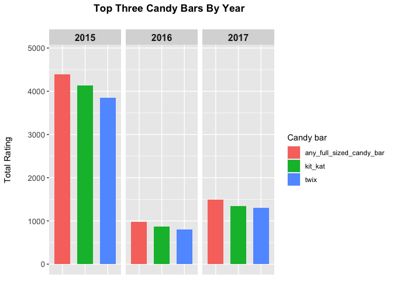

### Ratings (per year / per gender)

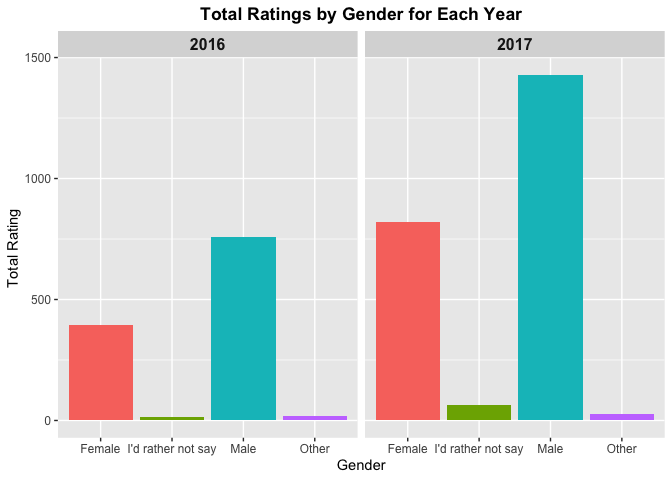

#### Missing values (per year / per gender / per country)

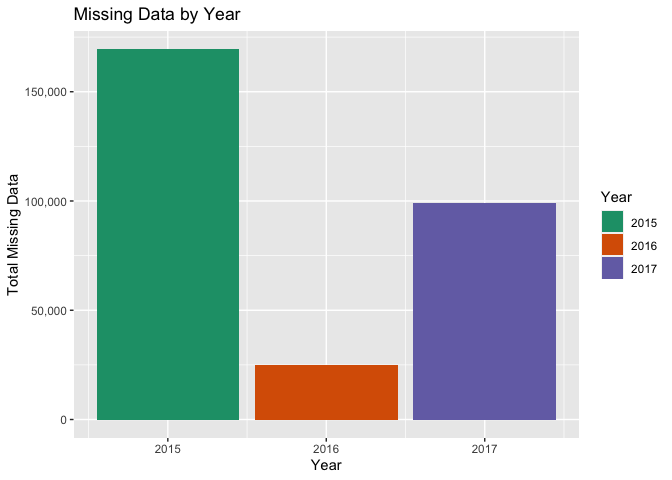

#### Missing data by Gender

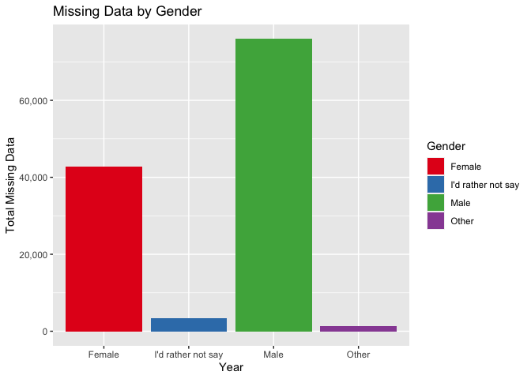

### Missing data by country:

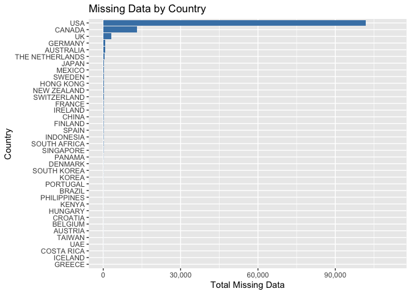

# Conclusion

After analyzing the candy surveys dataset, we can conclude that the average age of people who go out for trick or treating is 35, while the average age of people who do not go out is 39.

In terms of yearly popularity, any full-sized candy bar was the most popular candy bar for 2015, 2016, and 2017, with 4392, 982, and 1497 ratings respectively.

Finally, we found that the highest-rated candy bar by country was any full-sized candy bar, which was the top-rated candy bar for the USA, Canada, the UK, and Germany.

It is worth noting that there were many missing data points in the dataset, with the majority of them coming from the USA (101834 NAs), followed by Canada (13179 NAs) and the UK (3100 NAs). Overall, this analysis provides valuable insights into candy preferences and trick-or-treating habits among different demographics.

# Reference

[Candy dataset/surveys](https://www.scq.ubc.ca/so-much-candy-data-seriously/)